[figure not shown]

# Formula 1 Strategy Prediction and Visualization

## The Pre-processing

#### The dataset encompasses Formula 1 from 1950 to 2024 and while that range may be useful for other tasks it will just add extra noise and dilute the relationship between qualifying pace and average lap time. I decided to limit the data from 2014-2021 as that will encompass the entire turbo-hybrid era so it will allow for a large amount of data to look through while keeping it in a generally similar set of engine and aero regulations. There are 3 qualifying sessions that we will end up using with drivers getting knocked out each round depending on their position in qualifying.

```python
import pandas as pd
df = pd.read_csv('Downloads/archive/lap_times.csv')
df.head()
```

|  | raceId | driverId | lap | position | time | milliseconds |
| --- | --- | --- | --- | --- | --- | --- |
| 0 | 841 | 20 | 1 | 1 | 1:38.109 | 98109 |
| 1 | 841 | 20 | 2 | 1 | 1:33.006 | 93006 |
| 2 | 841 | 20 | 3 | 1 | 1:32.713 | 92713 |
| 3 | 841 | 20 | 4 | 1 | 1:32.803 | 92803 |
| 4 | 841 | 20 | 5 | 1 | 1:32.342 | 92342 |

```python
df = pd.read_csv('Downloads/archive/races.csv')

filtered_races = df[(df['year'] >= 2014) & (df['year'] <= 2021)]
race_ids = filtered_races['raceId'].tolist()

print(race_ids)
```

```
[900, 901, 902, 903, 904, 905, 906, 907, 908, 909, 910, 911, 912, 913, 914, 915, 916, 917, 918, 931, 932, 929, 930, 928, 926, 927, 933, 934, 936, 937, 938, 939, 940, 941, 942, 943, 944, 945, 948, 949, 950, 951, 952, 953, 954, 955, 956, 957, 958, 959, 960, 961, 962, 963, 964, 965, 966, 967, 968, 969,…
```

```python
df = pd.read_csv('Downloads/archive/lap_times.csv')
```

```python
filtered_laptimes = df[(df['raceId'] >= 900) & (df['raceId'] <= 1073)]
```

```python
print(filtered_laptimes)
```

```
        raceId  driverId  lap  position      time  milliseconds
72130      900         3    1         1  1:42.038        102038
72131      900         3    2         1  1:37.687         97687
72132      900         3    3         1  1:35.765         95765
72133      900         3    4         1  1:34.939         94939
72134      900         3    5         1  1:35.438         95438
...        ...       ...  ...       ...       ...           ...
514587    1073       847   22        15  1:30.821         90821
514588    1073       847   23        15  1:30.647         90647
514589    1073       847   24        14  1:31.577         91577
514590    1073       847   25        16  1:32.794         92794
514591    1073       847   26        18  2:46.262        166262

[173655 rows x 6 columns]
```

#### I am provided with every individual lap in the race but I need to find the average lap time of each race for my purposes. To accomplish this I am using the mean function to get the average lap time in milliseconds for each driver in each race.

```python
avg_times = filtered_laptimes.groupby(['raceId', 'driverId'])['milliseconds'].mean().reset_index()
```

```python
print(avg_times)
```

```
      raceId  driverId   milliseconds
0        900         1  103207.500000
1        900         3   97872.105263
2        900         4   98491.122807
3        900         8   98883.947368
4        900        16   99765.214286
...      ...       ...            ...
3158    1073       846   94423.189655
3159    1073       847   95032.884615
3160    1073       849   92309.820000
3161    1073       852   93500.637931
3162    1073       854   95192.052632

[3163 rows x 3 columns]
```

```python
df = pd.read_csv('Downloads/archive/qualifying.csv')
df.head()
```

|  | qualifyId | raceId | driverId | constructorId | number | position | q1 | q2 | q3 |
| --- | --- | --- | --- | --- | --- | --- | --- | --- | --- |
| 0 | 1 | 18 | 1 | 1 | 22 | 1 | 1:26.572 | 1:25.187 | 1:26.714 |
| 1 | 2 | 18 | 9 | 2 | 4 | 2 | 1:26.103 | 1:25.315 | 1:26.869 |
| 2 | 3 | 18 | 5 | 1 | 23 | 3 | 1:25.664 | 1:25.452 | 1:27.079 |
| 3 | 4 | 18 | 13 | 6 | 2 | 4 | 1:25.994 | 1:25.691 | 1:27.178 |
| 4 | 5 | 18 | 2 | 2 | 3 | 5 | 1:25.960 | 1:25.518 | 1:27.236 |

#### As you can see the qualifying times are in the minutes format so I will need to convert them to milliseconds so I can use them to compare against my average lap time.

```python
    def time_to_ms(time_str):
        if pd.isna(time_str):
            return None
        try:
            minutes, seconds = time_str.split(':')
            return (float(minutes) * 60 + float(seconds)) * 1000
        except:
            return None
```

```python
    qual_data = df[['raceId', 'driverId', 'q1', 'q2','q3']].copy()
    qual_data['q1_ms'] = qual_data['q1'].apply(time_to_ms)
    qual_data['q2_ms'] = qual_data['q2'].apply(time_to_ms)
    qual_data['q3_ms'] = qual_data['q3'].apply(time_to_ms)
```

#### I am now going to put my relevant qualifying time in ms data into a seperate dataframe along with my average lap time which is denoted by milliseconds.

```python
    result = pd.merge(
        avg_times,
        qual_data[['raceId', 'driverId', 'q1_ms','q2_ms','q3_ms']],
        on=['raceId', 'driverId'],
        how='left'
    )
```

```python
    result = result.sort_values(['raceId', 'driverId'])
```

result.head()

```python
print(result)
```

```
      raceId  driverId   milliseconds    q1_ms     q2_ms     q3_ms
0        900         1  103207.500000  91699.0  102890.0  104231.0
1        900         3   97872.105263  92564.0  102264.0  104595.0
2        900         4   98491.122807  91388.0  102805.0  105819.0
3        900         8   98883.947368  92439.0  104494.0       NaN
4        900        16   99765.214286  93673.0  105655.0       NaN
...      ...       ...            ...      ...       ...       ...
3158    1073       846   94423.189655  83553.0   83256.0   82931.0
3159    1073       847   95032.884615  84423.0       NaN       NaN
3160    1073       849   92309.820000  84338.0       NaN       NaN
3161    1073       852   93500.637931  83428.0   83404.0   83220.0
3162    1073       854   95192.052632  84906.0       NaN       NaN

[3163 rows x 6 columns]
```

#### Now that all of our data is together lets start cleaning it by making sure that there are no null values or duplicates to mess us up. We'll also make sure that the data types of the columns that we will use are the same

```python
result.isnull().sum()
```

```
raceId             0
driverId           0
milliseconds       0
q1_ms             52
q2_ms            858
q3_ms           1651
dtype: int64
```

```python
result = result.dropna()
```

```python
result.isnull().sum()
```

```
raceId          0
driverId        0
milliseconds    0
q1_ms           0
q2_ms           0
q3_ms           0
dtype: int64
```

```python
result.duplicated().sum()
```

```
0
```

```python
result.dtypes
```

```
raceId            int64
driverId          int64
milliseconds    float64
q1_ms           float64
q2_ms           float64
q3_ms           float64
dtype: object
```

#### Now that the data has been sufficiently cleaned and we can be confident of there being minimal noise we can start plotting out qualifying time against our average lap time to discern if there is a linear relationship to be found.

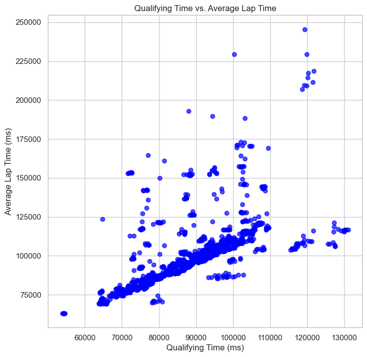

```python
import matplotlib.pyplot as plt
plt.figure(figsize=(8, 8))
plt.scatter(result["q1_ms"], result["milliseconds"], alpha=0.7, color='blue')
plt.xlabel("Qualifying Time (ms)")
plt.ylabel("Average Lap Time (ms)")
plt.title("Qualifying Time vs. Average Lap Time")
plt.grid(True)
plt.show()
```

#### As you can see there seems to be a positive linear relationship between our data so we can attempt to train a linear regression model to assist us in our predictions of average lap times.

```python
from sklearn.model_selection import train_test_split
X = result[['q1_ms']]
Y = result[['milliseconds']]
X_train, X_test, y_train, y_test = train_test_split(X, Y, test_size=0.2, random_state=47)
```

```python
from sklearn.linear_model import LinearRegression

model = LinearRegression()
model.fit(X_train, y_train)

print(f"Intercept: {model.intercept_}")
print(f"Coefficient: {model.coef_[0]}")
```

```
Intercept: [3088.81425648]
Coefficient: [1.10820083]
```

```
Mean Squared Error: 260996767.91269776
R-squared: 0.34889545545538214
```

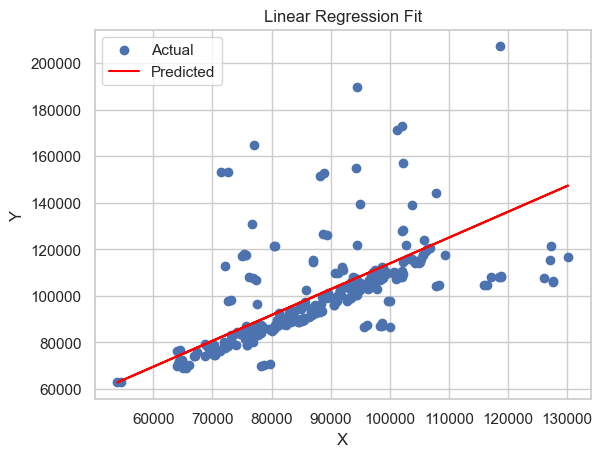

```python
from sklearn.metrics import mean_squared_error, r2_score

y_pred = model.predict(X_test)

mse = mean_squared_error(y_test, y_pred)
r2 = r2_score(y_test, y_pred)

print(f"Mean Squared Error: {mse}")
print(f"R-squared: {r2}")
plt.scatter(X_test, y_test, label="Actual")
plt.plot(X_test, y_pred, color='red', label="Predicted")
plt.xlabel('X')
plt.ylabel('Y')
plt.title('Linear Regression Fit')
plt.legend()
plt.show()
```

#### Dang. It seems that our R-squared value and Mean squared error are not great. It seems that most of our data is bunched around the same general trend but that our model is being messed up by several large outliers. These outliers could be caused by a crash ruining someone's qualifying lap or inclement weather affecting the general lap times recorded. Let us try removing those outliers and see if it improves our model.

```python
Q1 = result['milliseconds'].quantile(0.25)
Q3 = result['milliseconds'].quantile(0.75)
IQR = Q3 - Q1
lower_bound = Q1 - 1.5 * IQR
upper_bound = Q3 + 1.5 * IQR
result_test = result[(result['milliseconds'] >= lower_bound) & (result['milliseconds'] <= upper_bound)]
```

```python
from sklearn.model_selection import train_test_split
X = result_test[['q1_ms']]
Y = result_test[['milliseconds']]
X_train, X_test, y_train, y_test = train_test_split(X, Y, test_size=0.2, random_state=47)
```

```python
from sklearn.linear_model import LinearRegression
model = LinearRegression()
model.fit(X_train, y_train)
print(f"Intercept: {model.intercept_}")
print(f"Coefficient: {model.coef_[0]}")
```

```
Intercept: [19545.38952198]
Coefficient: [0.87776731]
```

```
Mean^2 Error: 75604177.55762616
R^2: 0.6312035187946355
```

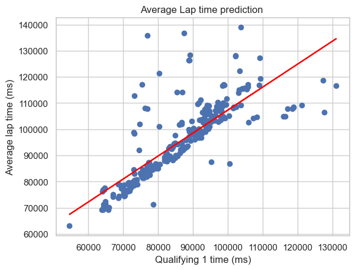

```python
from sklearn.metrics import mean_squared_error, r2_score

y_pred = model.predict(X_test)

mse = mean_squared_error(y_test, y_pred)
r2 = r2_score(y_test, y_pred)

print(f"Mean^2 Error: {mse}")
print(f"R^2: {r2}")

plt.scatter(X_test, y_test, label="Actual")
plt.plot(X_test, y_pred, color='red', label="Predicted")
plt.xlabel('Qualifying 1 time (ms)')
plt.ylabel('Average lap time (ms)')
plt.title('Average Lap time prediction ')
plt.show()
```

#### That looks much better with a R-squared value of 0.63 we can confidently say that our model provides a reasonable prediction for average lap time based off of qualifying time. Our Mean^2 error still seems a little large but that is mostly due to our measurements being in milliseconds and still having outliers that don't represent majority of the data. We've covered Q1 results but will Q2 and Q3 have a stronger relationship with average lap time? After all drivers do generally push more in Q2 and Q3 and many of the stops are pulled out.

```python
from sklearn.model_selection import train_test_split
X = result[['q2_ms']]
Y = result[['milliseconds']]
X_train, X_test, y_train, y_test = train_test_split(X, Y, test_size=0.2, random_state=47)
```

```python
from sklearn.linear_model import LinearRegression
model = LinearRegression()
model.fit(X_train, y_train)
print(f"Intercept: {model.intercept_}")
print(f"Coefficient: {model.coef_[0]}")
```

```
Intercept: [2980.83724266]
Coefficient: [1.11806022]
```